# Basic SIR Model

Jamie Prentice

2026-02-05

# Load libraries and source files

This pulls in all the necessary libraries and source files

```r
source("libraries.R")
source("source_files.R")
```

# Generating a params list

The first step is to generate a params list that contains the basic information, with some messages to note exactly what it’s using. All elements in `make_parameters()` have default values, so these are just to see what you can add.

The params list might not fully do everything we want, but as it is just a basic R list, we can easily modify it afterwards.

```r
params <- make_parameters(
    model_type = "SIR",  # a Susceptible-Infected-Removed model
    setup = "single",    # a single group
    use_traits = "none", # no genetic effects applied to traits
    sim_new_data = "r"   # simulate in R (rather than in BICI)
)
```

This provides a short summary of the params

```r
summarise_params(params)
```

```
## Simulating new SIR data via R
```

```
## - Demography is:
##  10 sires, 20 dams, 500 progeny (530 total)
##  1 group (group size 500)
```

```
## - Individual Effects on:
##  none
```

```
## - Sigma_G:
```

```
##     sus inf tol
## sus   0   0   0
## inf   0   0   0
## tol   0   0   0
```

```
## - Fixed Effects are:
##  Trial = 'none', Donor = 'none', TxD = 'none', Weight = 'none'
```

```
## - Estimated R0:
##  5
```

```
## - Running MCMC with:
##  10,000 updates, 10,000 samples, 0.2 burnin, 16 chains
## - BICI script file:
##  'datasets/testing/data/scen-1-1.bici'
## - Results file:
##  'datasets/testing/results/scen-1-1.rds'
```

# Generate pedigree and popn

Next we take the `params` file and use it to generate a population with groups, traits, weights, and fixed effects applied to the phenotypes. Note that you these are piped into each other, but you can save the intermediate result at any point to examine what’s happening (e.g. for bug fixing).

First `make_pedigree()` creates a population with the appropriate structure (this may be a balanced population with given numbers of sires, dams per sire, and progeny per dam, it may copy an existing structure, or you can just set your own structure)

```r
popn <- make_pedigree(params) |>
    set_groups(params) |>
    set_traits(params) |>
    set_weights(params) |>
    apply_fixed_effects(params)
```

It’s worth taking a look at the `popn` file to see what it includes. The columns are:

```r
names(popn)
```

```
##  [1] "id"     "sire"   "dam"    "sdp"    "trial"  "group"  "weight" "donor"
##  [9] "GE"     "sus_g"  "inf_g"  "tol_g"  "sus_e"  "inf_e"  "tol_e"  "sus"
## [17] "inf"    "tol"
```

Where:

A typical progeny looks like:

```r
popn[sdp == "progeny"][1] |>
    knitr::kable("html")
```

| id | sire | dam | sdp | trial | group | weight | donor | GE | sus_g | inf_g | tol_g | sus_e | inf_e | tol_e | sus | inf | tol |
| --- | --- | --- | --- | --- | --- | --- | --- | --- | --- | --- | --- | --- | --- | --- | --- | --- | --- |
| 31 | 1 | 11 | progeny | 1 | 1 | 50 | 1 | 1 | 0 | 0 | 0 | 0 | 0 | 0 | 1 | 1 | 1 |

# Simulate and plot epidemic

We now pass the population file `popn` and the parameters `params` to `simulate_epidemic()`, which will run the appropriate model and return a *new* `popn` file with event times, final status, which generation infective they were, and the individual responsible for their infection. You can generate multiple realisations of the epidemic from the same inputs if you save the `popn` output each time.

```r
tic(); popn <- simulate_epidemic(popn, params); toc()
```

```
## 8.05 sec elapsed
```

We can also use the generation value to calculate $R_0$, which is the mean across all groups of the ratio of secondary to primary infectives. Also it’s useful to see how long the epidemic took until it completed (since this information is necessary for BICI to use).

```r
params$estimated_R0 <- get_R0(popn)
```

```
## R0 estimate: 7.4
```

```r
params$tmax <- get_tmax(popn, params)

message("Tmax = [", str_flatten_comma(round(params$tmax, 1)), "]")
```

```
## Tmax = [78.6]
```

The progeny we had before now looks like this, with the additional columns:

- `Tinf`: the infection time ($t:S\rightarrow E$). In actual data this is 0 for inoculated individuals, and missing for all others.
- `Tinc`: the incubation time ($t:E\rightarrow I$), missing in the data.
- `Tsym`: the time of symptoms ($t:I\rightarrow D$), present in data.
- `Tdeath`: the time of death ($t:D\rightarrow R$), present in data.
- `status`: which compartment the individual is in at the end of the epidemic (should only be `S` or `R`)
- `generation`: if an individual is a primary, secondary, tertiary etc. infective.
- `infected_by`: the id of the individual responsible for this infection (0 for inoculated individuals).
- `parasites` `TRUE` if an individual was infected. In actual data the sensitivity is not 100%.

```r
popn[sdp == "progeny",
     .(id, donor, Tinf, Tdeath, status, generation, infected_by)][1:10] |>
    knitr::kable("html")
```

| id | donor | Tinf | Tdeath | status | generation | infected_by |
| --- | --- | --- | --- | --- | --- | --- |
| 31 | 1 | 0.00000 | 22.381736 | R | 1 | 0 |
| 32 | 1 | 0.00000 | 10.104750 | R | 1 | 0 |
| 33 | 1 | 0.00000 | 0.144765 | R | 1 | 0 |
| 34 | 1 | 0.00000 | 3.853585 | R | 1 | 0 |
| 35 | 1 | 0.00000 | 3.714627 | R | 1 | 0 |
| 36 | 0 | 23.51434 | 39.132388 | R | NA | 111 |
| 37 | 0 | 29.20198 | 41.491427 | R | NA | 57 |
| 38 | 0 | 13.60348 | 15.852539 | R | NA | 21 |
| 39 | 0 | 20.38388 | 45.431064 | R | NA | 61 |
| 40 | 0 | 24.00863 | 52.788157 | R | NA | 104 |

# Plot the epidemic

We can take a look at the time trajectory

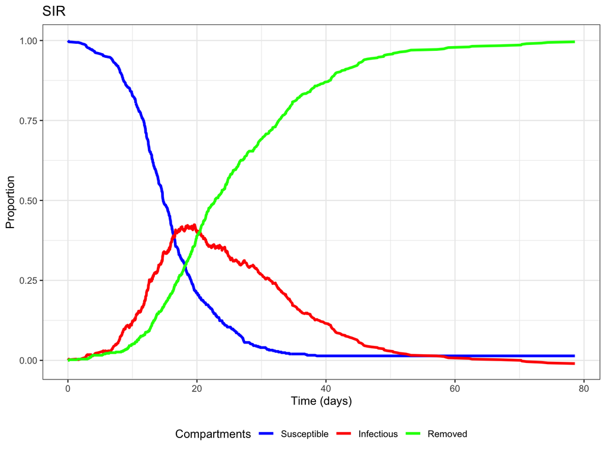

```r
p1a <- plot_model(popn, params)
```

It’s also important to look at the Kaplan-Meier survival plot.

```r
p1b <- basic_km(popn, params)
```

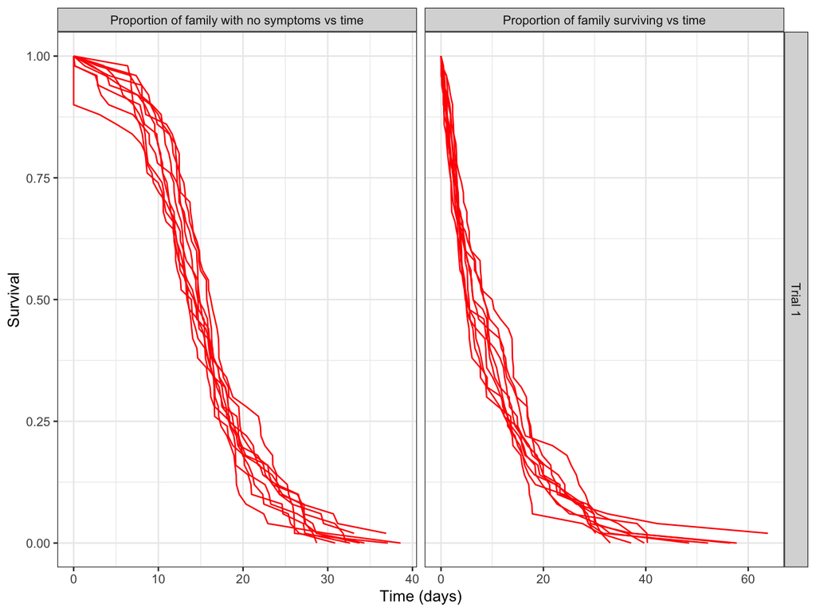

# Add in genetic variance

```r
params2 <- make_parameters(
    model_type = "SIR", # a Susceptible-Infected-Removed model
    setup = "single",   # a single group
    use_traits = "sit", # no genetic effects applied to traits
    vars = list(sus = 0.5, inf = 1, tol = 0.2),
    cors = list(si = 0.3, st = -0.2, it = 0.2),
    sim_new_data = "r"  # simulate in R (rather than in BICI)
)
```

A quick look at the summary

```r
summarise_params(params2)
```

```
## Simulating new SIR data via R
```

```
## - Demography is:
##  10 sires, 20 dams, 500 progeny (530 total)
##  1 group (group size 500)
```

```
## - Individual Effects on:
##  sus, inf, tol
```

```
## - Sigma_G:
```

```
##      sus inf  tol
## sus  0.5 0.3 -0.2
## inf  0.3 1.0  0.2
## tol -0.2 0.2  0.2
```

```
## - Fixed Effects are:
##  Trial = 'none', Donor = 'none', TxD = 'none', Weight = 'none'
```

```
## - Estimated R0:
##  5
```

```
## - Running MCMC with:
##  10,000 updates, 10,000 samples, 0.2 burnin, 16 chains
## - BICI script file:
##  'datasets/testing/data/scen-1-1.bici'
## - Results file:
##  'datasets/testing/results/scen-1-1.rds'
```

Now rebuild the population

```r
popn2 <- make_pedigree(params2) |>
    set_groups(params2) |>
    set_traits(params2) |>
    set_weights(params2) |>
    apply_fixed_effects(params2)
```

If we look at some of the individuals, we can see that they now have individual values for their genotypes, and different phenotypes

```r
popn2[sdp == "progeny", map(.SD, round, 2),
     .SDcols = str_subset(names(popn2), "id|sus|inf|tol")][1:5] |>
    knitr::kable("html")
```

| id | sus_g | inf_g | tol_g | sus_e | inf_e | tol_e | sus | inf | tol |
| --- | --- | --- | --- | --- | --- | --- | --- | --- | --- |
| 31 | -0.27 | 1.09 | -0.94 | -1.15 | 0.06 | -0.01 | 0.24 | 3.15 | 0.39 |
| 32 | -0.25 | -0.24 | -0.57 | -0.79 | 0.45 | -0.92 | 0.36 | 1.23 | 0.23 |
| 33 | -0.41 | -2.22 | -0.57 | -0.42 | -1.07 | -0.81 | 0.44 | 0.04 | 0.25 |
| 34 | -0.10 | -0.24 | -1.66 | 0.51 | 1.12 | -1.23 | 1.50 | 2.41 | 0.06 |
| 35 | -0.74 | -1.34 | -0.49 | -1.18 | 0.42 | 0.41 | 0.15 | 0.40 | 0.92 |

We can now run a simulation with the new setup

```r
popn2 <- simulate_epidemic(popn2, params2)
get_R0(popn2)
```

```
## [1] 0.4
```

# Plot the epidemic

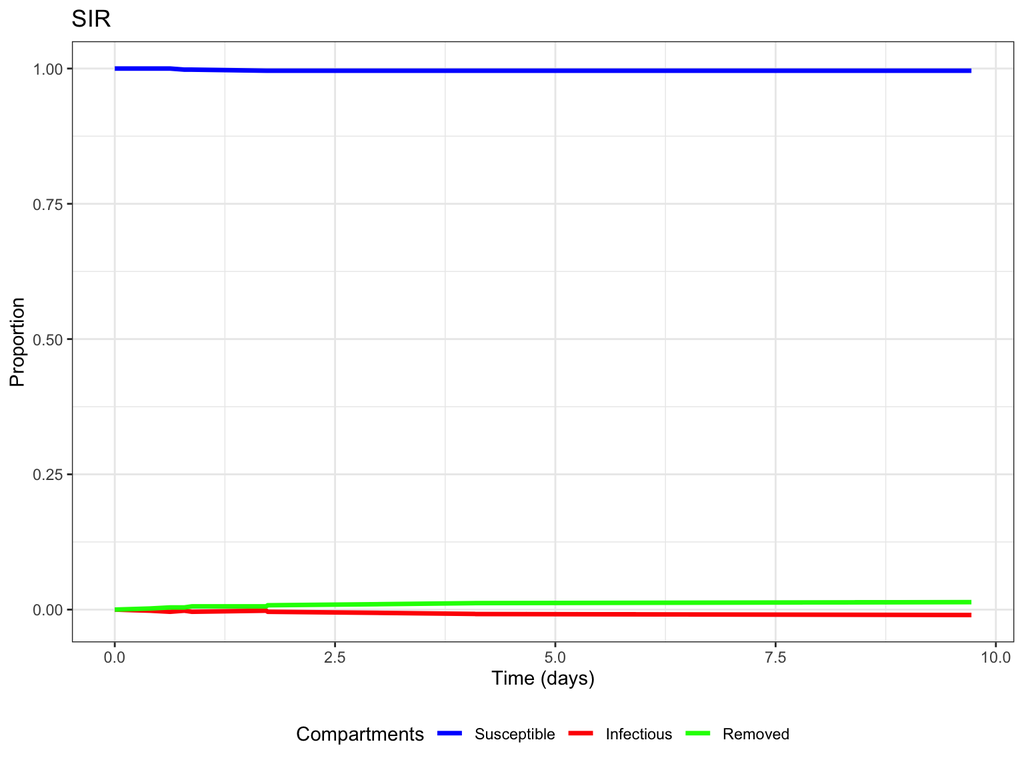

```r
p2a <- plot_model(popn2, params2)
```

```r
p2b <- basic_km(popn2, params2)
```

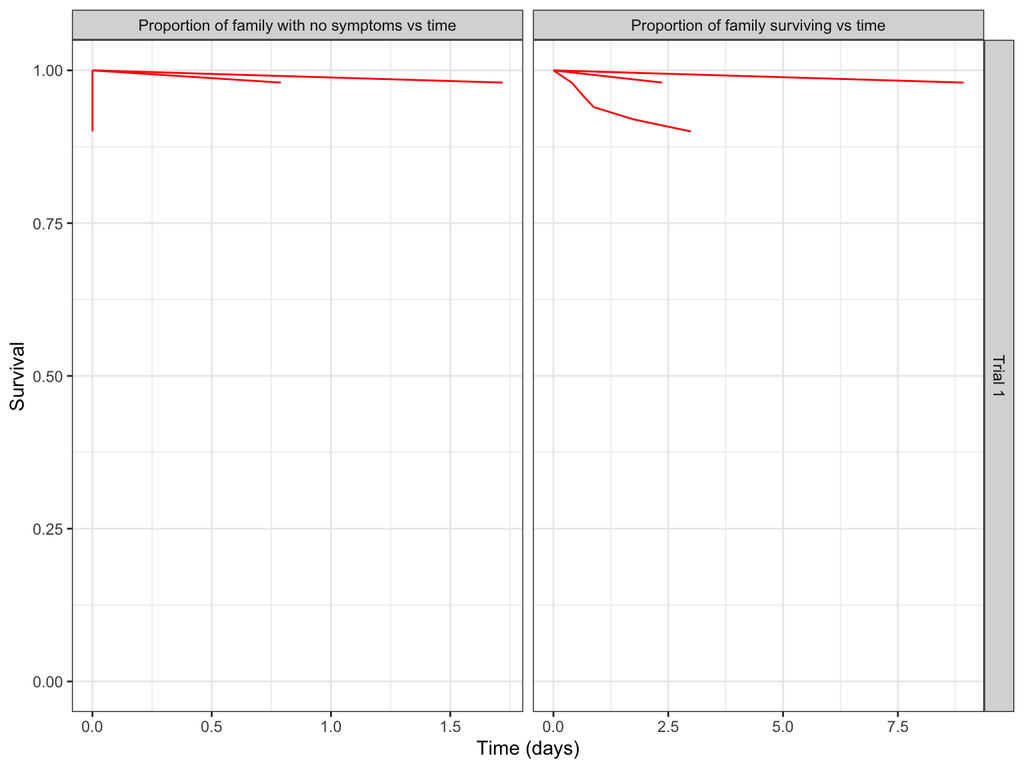

Now we can add in some fixed effects.

```r
params3 <- make_parameters(
    model_type = "SIR", # a Susceptible-Infected-Removed model
    setup = "multiple", # a single group
    use_traits = "sit", # no genetic effects applied to traits
    vars = list(sus = 0.5, inf = 1, tol = 0.2),
    cors = list(si = 0.3, st = -0.2, it = 0.2),
    donor_fe = "it",    # donor FE on inf, tol
    weight_fe = "sit",  # weight FE on sus, inf, tol
    sim_new_data = "r"  # simulate in R (rather than in BICI)
)
summarise_params(params3)
```

[output not shown]

There’s one more step here, we need to specify the FE values we want to use. It’s just a matrix containing all the combinations.

```r
params3$fe_vals["donor", "inf"] <- 1
params3$fe_vals["donor", "tol"] <- -1
params3$fe_vals["weight", c("sus", "inf", "tol")] <- c(-0.5, 0.5, 0.5)
params3$fe_vals[, params3$model_traits]
```

```
##          traits
## fe         sus inf  tol
##   trial    0.0 0.0  0.0
##   donor    0.0 1.0 -1.0
##   txd      0.0 0.0  0.0
##   weight  -0.5 0.5  0.5
##   weight1  0.0 0.0  0.0
##   weight2  0.0 0.0  0.0
```

And generate and simulate

```r
popn3 <- make_pedigree(params3) |>
    set_groups(params3) |>
    set_traits(params3) |>
    set_weights(params3) |>
    apply_fixed_effects(params3) |>
    simulate_epidemic(params3)
```

And plot

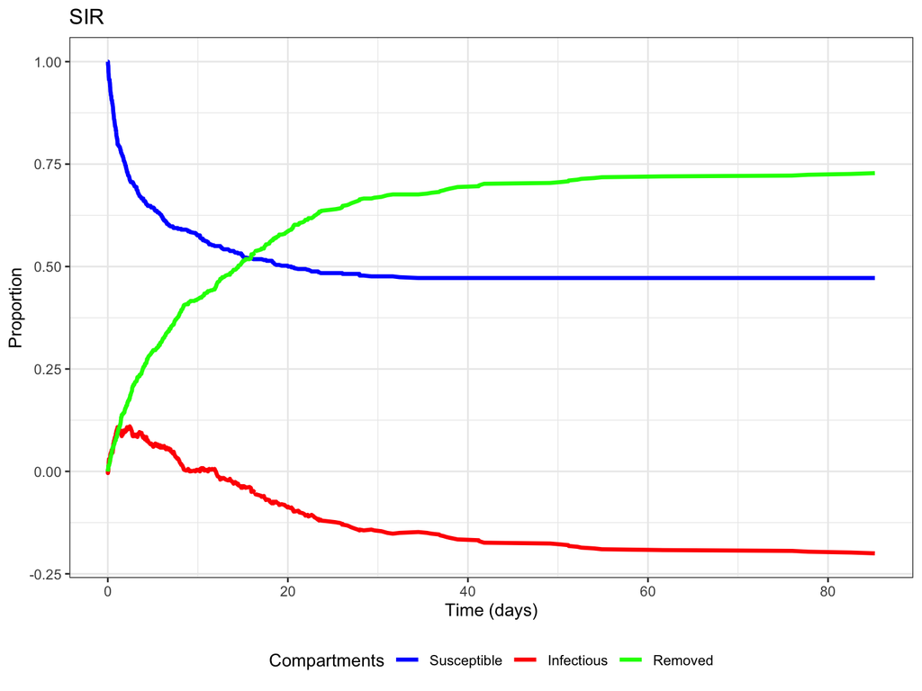

```r
p2a <- plot_model(popn3, params3)
```

```r
p2b <- basic_km(popn3, params3)
```

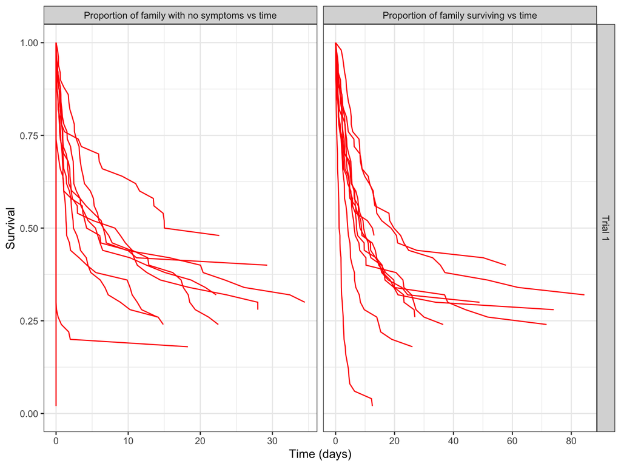